# SBST Abstract: Anchoring & TSP Enrollment: *Suggesting contribution rates promotes savings enrollment and contributions*

Paul Testa and Jake Bowers

August 17, 2016

# Agency Objective.

Increase enrollment and contribution rates in Thrift Savings Plans among interested active duty Servicemembers using behaviorally designed email communications.

# Background

The Federal government operates a workplace savings program called the Thrift Savings Plan (TSP) for all of its employees.[^1] While the Government automatically enrolls its civilian employees in TSP, it does not automatically enroll Servicemembers, and military enrollment rates average roughly 42 percent.[^2] In order to enroll, Servicemembers need to log in to a website and select from a suite of potential contribution percentages. A 2015 Department of Defense (DOD) and Social and Behavioral Sciences Team (SBST) study showed that many of the nearly 800,000 unenrolled Servicemembers chose to enroll in TSP when actively emailed about a chance to do so.

# Design

```r
# Load data
tsp<-read.dta13("~/Documents/sbst/tsp/all_indiv.dta")
# Recode treatment
tsp$treatment<-recode(tsp$Group, "0='Control';
                      9='No Suggestion'
                      ")
# Re-order levels of factor
tsp$treatment<-factor(tsp$treatment,levels=c("Control","No Suggestion",1:8))

# Additional treatment indicators
# Suggestion or not
tsp$treat_type<-recode(tsp$treatment,"1:8='Suggestion'")
# Email type
tsp$treat_email<-ifelse(tsp$treatment=="Control","Control","Email")
```

# Results

One month after the emails were sent, 18,451 Servicemembers had enrolled: 1,362 in the no-email group (1.94%), compared with 1,813 who received an email with no suggested contribution rate (2.58%) and 15,276 across those sent the eight anchoring emails (2.73%).

```r
# Number enrolled
table(tsp$participate)
```

```
##
##      0      1
## 681196  18451
```

```r
# Enrollment by Treatment Type
table(tsp$participate,tsp$treat_type)
```

```
##
##     Control No Suggestion Suggestion
##   0   68725         68356     544115
##   1    1362          1813      15276
```

```r
# Use linear models to obtain proportions

m1<-lm(participate~treat_type,tsp)
props_type<-c(coef(m1)[1],coef(m1)[1]+coef(m1)[2:3])
props_type
```

```
##             (Intercept) treat_typeNo Suggestion    treat_typeSuggestion
##                0.019433                0.025838                0.027308
```

```r
# Test difference of proptions
coeftest(m1,vcov=vcovHC(m1,type="HC2") )
```

```
##
## t test of coefficients:
##
##                         Estimate Std. Error t value Pr(>|t|)
## (Intercept)             0.019433   0.000521   37.27  < 2e-16 ***
## treat_typeNo Suggestion 0.006405   0.000794    8.07  7.3e-16 ***
## treat_typeSuggestion    0.007875   0.000565   13.94  < 2e-16 ***
## ---
## Signif. codes:  0 '***' 0.001 '**' 0.01 '*' 0.05 '.' 0.1 ' ' 1
```

```r
# Test equality of No Suggested Rate vs Suggested Contribution Rate
linearHypothesis(m1,"treat_typeNo Suggestion=treat_typeSuggestion",vcov=vcovHC(m1,type="HC2") )
```

```
## Linear hypothesis test
##
## Hypothesis:
## treat_typeNo Suggestion - treat_typeSuggestion = 0
##
## Model 1: restricted model
## Model 2: participate ~ treat_type
##
## Note: Coefficient covariance matrix supplied.
##
##   Res.Df Df    F Pr(>F)
## 1 699645
## 2 699644  1 5.32  0.021 *
## ---
## Signif. codes:  0 '***' 0.001 '**' 0.01 '*' 0.05 '.' 0.1 ' ' 1
```

Emails with suggested contribution anchors ranged from a low of 2.49% (for a 7 percent suggestion) to a high of 2.97% (for a 1 percent suggestion).

```r
# Use linear models to obtain proportions by suggested contribution rate

m2<-lm(participate~treatment,tsp)
props_sc<-c(coef(m2)[1],coef(m2)[1]+coef(m2)[2:10])
props_sc
```

```
##            (Intercept) treatmentNo Suggestion             treatment1             treatment2
##               0.019433               0.025838               0.029665               0.029282
##             treatment3             treatment4             treatment5             treatment6
##               0.027148               0.026888               0.026993               0.026870
##             treatment7             treatment8
##               0.024861               0.026752
```

```r
range(props_sc[2:10])
```

```
## [1] 0.024861 0.029665
```

```r
coeftest(m2,vcov=vcovHC(m2,type="HC2") )
```

```
##
## t test of coefficients:
##
##                        Estimate Std. Error t value Pr(>|t|)
## (Intercept)            0.019433   0.000521   37.27  < 2e-16 ***
## treatmentNo Suggestion 0.006405   0.000794    8.07  7.3e-16 ***
## treatment1             0.010232   0.000827   12.38  < 2e-16 ***
## treatment2             0.009849   0.000823   11.97  < 2e-16 ***
## treatment3             0.007715   0.000806    9.57  < 2e-16 ***
## treatment4             0.007455   0.000805    9.26  < 2e-16 ***
## treatment5             0.007560   0.000804    9.40  < 2e-16 ***
## treatment6             0.007437   0.000803    9.26  < 2e-16 ***
## treatment7             0.005428   0.000786    6.90  5.1e-12 ***
## treatment8             0.007319   0.000803    9.11  < 2e-16 ***
## ---
## Signif. codes:  0 '***' 0.001 '**' 0.01 '*' 0.05 '.' 0.1 ' ' 1
```

This means that 40 percent more Servicemembers enrolled in TSP in February 2016 as a result of being sent any email message.

```r
# Effect of receiving any email
m3<-lm(participate~treat_email,tsp)
props_email<-c(coef(m3)[1],coef(m3)[1]+coef(m3)[2])
props_email
```

```
## (Intercept) (Intercept)
##    0.019433    0.027144
```

```r
(1-props_email[2]/props_email[1])*100
```

```
## (Intercept)
##     -39.682
```

```r
coeftest(m3,vcov=vcovHC(m3,type="HC2") )
```

```
##
## t test of coefficients:
##
##                  Estimate Std. Error t value Pr(>|t|)
## (Intercept)      0.019433   0.000521    37.3   <2e-16 ***
## treat_emailEmail 0.007711   0.000560    13.8   <2e-16 ***
## ---
## Signif. codes:  0 '***' 0.001 '**' 0.01 '*' 0.05 '.' 0.1 ' ' 1
```

Suggesting low contribution rates (1% and 2%) led to slightly higher new enrollments, but those suggestions also led to lower average contribution rates among those that contributed. From 3% up to 8%, increasing the suggested contribution rate did not depress savings.

```r
# Compare contributions rates to just baseline email
m4<-lm(participate~treatment,tsp[tsp$treatment!="Control",])
coeftest(m4,vcov=vcovHC(m4,type="HC2") )
```

```
##
## t test of coefficients:
##
##              Estimate Std. Error t value Pr(>|t|)
## (Intercept)  0.025838   0.000599   43.14  < 2e-16 ***
## treatment1   0.003828   0.000878    4.36 0.000013 ***
## treatment2   0.003444   0.000874    3.94 0.000082 ***
## treatment3   0.001310   0.000858    1.53     0.13
## treatment4   0.001050   0.000857    1.23     0.22
## treatment5   0.001155   0.000857    1.35     0.18
## treatment6   0.001033   0.000855    1.21     0.23
## treatment7  -0.000977   0.000840   -1.16     0.24
## treatment8   0.000914   0.000856    1.07     0.29
## ---
## Signif. codes:  0 '***' 0.001 '**' 0.01 '*' 0.05 '.' 0.1 ' ' 1
```

For each of the eight suggested contribution rates, there was some evidence suggestive of an anchoring effect – Servicemembers were more likely to contribute at exactly the suggested rate than those who were not given a suggested rate.

```r
# Anchoring
table(tsp$totalcont)
```

```
##
##      0      1      2      3      4      5      6      7      8      9     10     11     12     13
## 681198   1830   1865   1383    959   4083    758    636    577    117   3504    130    238     90
##     14     15     16     17     18     19     20     21     22     23     24     25     26     27
##     74    783     57     56     37     13    571     18     14     20     14    174      8     13
##     28     29     30     31     32     33     34     35     36     37     38     39     40     41
##      7      1    109      4      3     13      5     29      3      4      4      2     44      1
##     42     45     46     50     51     52     54     55     58     59     60     62     63     65
##      1      6      2     47      3      1      1      1      3      2     79      1      1      3
##     68     70     72     73     74     75     77     80     90     92     95    100
##      1      2      2      1      1      2      1      1      1     18      1     16
```

```r
# Create indicator of contribution at suggested rate
tsp$contrib_at_suggest<-tsp$totalcont==tsp$treatment
# Indicator of Individual rates
tsp$contrib_1<-as.numeric(tsp$totalcont==1)
tsp$contrib_2<-as.numeric(tsp$totalcont==2)
tsp$contrib_3<-as.numeric(tsp$totalcont==3)
tsp$contrib_4<-as.numeric(tsp$totalcont==4)
tsp$contrib_5<-as.numeric(tsp$totalcont==5)
tsp$contrib_6<-as.numeric(tsp$totalcont==6)
tsp$contrib_7<-as.numeric(tsp$totalcont==7)
tsp$contrib_8<-as.numeric(tsp$totalcont==8)

# Suggested Rate: 1
m_c_1<-lm(contrib_1~treatment,tsp[tsp$treatment!="Control",])
coeftest(m_c_1,vcovHC(m_c_1,type="HC2"))
```

```
##
## t test of coefficients:
##
##              Estimate Std. Error t value    Pr(>|t|)
## (Intercept) 0.0022945  0.0001806   12.70     < 2e-16 ***
## treatment1  0.0016085  0.0002970    5.42 0.000000061 ***
## treatment2  0.0001588  0.0002599    0.61        0.54
## treatment3  0.0001488  0.0002597    0.57        0.57
## treatment4  0.0002505  0.0002629    0.95        0.34
## treatment5  0.0000764  0.0002577    0.30        0.77
## treatment6  0.0003883  0.0002661    1.46        0.14
## treatment7  0.0001073  0.0002586    0.41        0.68
## treatment8  0.0003291  0.0002648    1.24        0.21
## ---
## Signif. codes:  0 '***' 0.001 '**' 0.01 '*' 0.05 '.' 0.1 ' ' 1
```

```r
# Suggested Rate: 2
m_c_2<-lm(contrib_2~treatment,tsp[tsp$treatment!="Control",])
coeftest(m_c_2,vcovHC(m_c_2,type="HC2"))
```

```
##
## t test of coefficients:
##
##                Estimate  Std. Error t value       Pr(>|t|)
## (Intercept)  0.00249398  0.00018829   13.25        < 2e-16 ***
## treatment1   0.00093719  0.00029041    3.23         0.0013 **
## treatment2   0.00212720  0.00031790    6.69 0.000000000022 ***
## treatment3  -0.00000784  0.00026625   -0.03         0.9765
## treatment4   0.00009416  0.00026939    0.35         0.7267
## treatment5  -0.00028026  0.00025885   -1.08         0.2789
## treatment6  -0.00009662  0.00026379   -0.37         0.7142
## treatment7  -0.00044963  0.00025421   -1.77         0.0769 .
## treatment8   0.00017261  0.00027126    0.64         0.5246
## ---
## Signif. codes:  0 '***' 0.001 '**' 0.01 '*' 0.05 '.' 0.1 ' ' 1
```

```r
# Suggested Rate: 3
m_c_3<-lm(contrib_3~treatment,tsp[tsp$treatment!="Control",])
coeftest(m_c_3,vcovHC(m_c_3,type="HC2"))
```

```
##
## t test of coefficients:
##
##               Estimate Std. Error t value Pr(>|t|)
## (Intercept)  0.0020664  0.0001714   12.05   <2e-16 ***
## treatment1   0.0003068  0.0002515    1.22    0.222
## treatment2   0.0002584  0.0002499    1.03    0.301
## treatment3   0.0005626  0.0002586    2.18    0.030 *
## treatment4  -0.0001541  0.0002384   -0.65    0.518
## treatment5  -0.0000955  0.0002398   -0.40    0.690
## treatment6  -0.0003540  0.0002319   -1.53    0.127
## treatment7  -0.0004796  0.0002281   -2.10    0.036 *
## treatment8  -0.0000737  0.0002406   -0.31    0.760
## ---
## Signif. codes:  0 '***' 0.001 '**' 0.01 '*' 0.05 '.' 0.1 ' ' 1
```

```r
# Suggested Rate: 4
m_c_4<-lm(contrib_4~treatment,tsp[tsp$treatment!="Control",])
coeftest(m_c_4,vcovHC(m_c_4,type="HC2"))
```

```
##
## t test of coefficients:
##
##              Estimate Std. Error t value    Pr(>|t|)
## (Intercept)  0.001311   0.000137    9.60     < 2e-16 ***
## treatment1   0.000233   0.000202    1.15      0.2483
## treatment2   0.000486   0.000210    2.31      0.0209 *
## treatment3   0.000346   0.000206    1.68      0.0922 .
## treatment4   0.001291   0.000237    5.46 0.000000048 ***
## treatment5  -0.000197   0.000186   -1.06      0.2889
## treatment6  -0.000184   0.000186   -0.99      0.3240
## treatment7  -0.000553   0.000172   -3.22      0.0013 **
## treatment8  -0.000308   0.000182   -1.69      0.0906 .
## ---
## Signif. codes:  0 '***' 0.001 '**' 0.01 '*' 0.05 '.' 0.1 ' ' 1
```

```r
# Suggested Rate: 5
m_c_5<-lm(contrib_5~treatment,tsp[tsp$treatment!="Control",])
coeftest(m_c_5,vcovHC(m_c_5,type="HC2"))
```

```
##
## t test of coefficients:
##
##                Estimate  Std. Error t value Pr(>|t|)
## (Intercept)  0.00584304  0.00028772   20.31  < 2e-16 ***
## treatment1   0.00007573  0.00040854    0.19    0.853
## treatment2   0.00073216  0.00041947    1.75    0.081 .
## treatment3   0.00034374  0.00041308    0.83    0.405
## treatment4   0.00000904  0.00040797    0.02    0.982
## treatment5   0.00171216  0.00043575    3.93 0.000085 ***
## treatment6  -0.00032054  0.00040144   -0.80    0.425
## treatment7  -0.00019606  0.00040381   -0.49    0.627
## treatment8  -0.00045251  0.00039956   -1.13    0.257
## ---
## Signif. codes:  0 '***' 0.001 '**' 0.01 '*' 0.05 '.' 0.1 ' ' 1
```

```r
# Suggested Rate: 6
m_c_6<-lm(contrib_6~treatment,tsp[tsp$treatment!="Control",])
coeftest(m_c_6,vcovHC(m_c_6,type="HC2"))
```

```
##
## t test of coefficients:
##
##                Estimate  Std. Error t value    Pr(>|t|)
## (Intercept)  0.00101184  0.00012002    8.43     < 2e-16 ***
## treatment1   0.00008899  0.00017357    0.51        0.61
## treatment2  -0.00004197  0.00016801   -0.25        0.80
## treatment3  -0.00001167  0.00016936   -0.07        0.95
## treatment4   0.00005217  0.00017230    0.30        0.76
## treatment5  -0.00004066  0.00016812   -0.24        0.81
## treatment6   0.00115720  0.00021282    5.44 0.000000054 ***
## treatment7  -0.00015408  0.00016327   -0.94        0.35
## treatment8   0.00000605  0.00017025    0.04        0.97
## ---
## Signif. codes:  0 '***' 0.001 '**' 0.01 '*' 0.05 '.' 0.1 ' ' 1
```

```r
# Suggested Rate: 7
m_c_7<-lm(contrib_7~treatment,tsp[tsp$treatment!="Control",])
coeftest(m_c_7,vcovHC(m_c_7,type="HC2"))
```

```
##
## t test of coefficients:
##
##                Estimate  Std. Error t value Pr(>|t|)
## (Intercept)  0.00074107  0.00010273    7.21  5.5e-13 ***
## treatment1   0.00017391  0.00015370    1.13    0.258
## treatment2   0.00034291  0.00016124    2.13    0.033 *
## treatment3  -0.00009810  0.00014048   -0.70    0.485
## treatment4  -0.00003652  0.00014379   -0.25    0.800
## treatment5   0.00024439  0.00015689    1.56    0.119
## treatment6   0.00020075  0.00015486    1.30    0.195
## treatment7   0.00090299  0.00018444    4.90  9.8e-07 ***
## treatment8   0.00000443  0.00014572    0.03    0.976
## ---
## Signif. codes:  0 '***' 0.001 '**' 0.01 '*' 0.05 '.' 0.1 ' ' 1
```

```r
# Suggested Rate: 8
m_c_8<-lm(contrib_8~treatment,tsp[tsp$treatment!="Control",])
coeftest(m_c_8,vcovHC(m_c_8,type="HC2"))
```

```
##
## t test of coefficients:
##
##               Estimate Std. Error t value       Pr(>|t|)
## (Intercept)  0.0006413  0.0000956    6.71 0.000000000019 ***
## treatment1   0.0002165  0.0001462    1.48          0.139
## treatment2  -0.0000993  0.0001298   -0.76          0.444
## treatment3   0.0002731  0.0001490    1.83          0.067 .
## treatment4   0.0000776  0.0001395    0.56          0.578
## treatment5   0.0000585  0.0001383    0.42          0.672
## treatment6   0.0002720  0.0001488    1.83          0.068 .
## treatment7   0.0002165  0.0001462    1.48          0.139
## treatment8   0.0009787  0.0001798    5.44 0.000000052154 ***
## ---
## Signif. codes:  0 '***' 0.001 '**' 0.01 '*' 0.05 '.' 0.1 ' ' 1
```

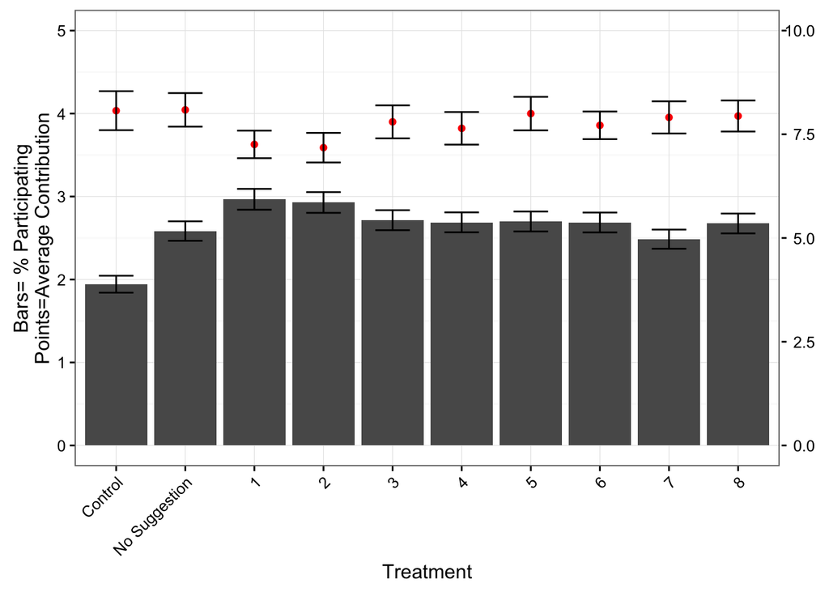

```r
# Reproduce Figure

# Calculate Proportions Participating
partic<-table(tsp$treatment)

partic_rate<-apply(table(tsp$participate,tsp$treatment),2,prop.table)[2,]
partic_df<-data.frame(treatment=names(partic_rate),rate=partic_rate,n=t(partic)[1,])
partic_df$se<-with(partic_df,sqrt(rate*(1-rate)/n))
partic_df$ll<-with(partic_df,rate-1.96*se)
partic_df$ul<-with(partic_df,rate+1.96*se)

# Express as percents
partic_df[,c("rate","ll","ul")]<-partic_df[,c("rate","ll","ul")]*100

# Calculate Average Contribtutions

contributors<-table(tsp$treatment,tsp$participate)[,2]

contrib_rate<-mean(totalcont~treatment,data=tsp[tsp$participate==1,])
contrib_sd<-sd(totalcont~treatment,data=tsp[tsp$participate==1,])

contrib_df<-data.frame(contrib=contrib_rate,
                       contrib_se=contrib_sd/sqrt(contributors)
                       )
contrib_df$contrib_ll<-with(contrib_df,contrib-1.96*contrib_se)
contrib_df$contrib_ul<-with(contrib_df,contrib+1.96*contrib_se)

plot_df<-cbind(partic_df,contrib_df)

grid.newpage()
plot_df$treatment<-factor(plot_df$treatment,levels=c("Control","No Suggestion",1:8))
# two plots
p1 <- ggplot(plot_df, aes(treatment, rate)) + geom_bar(stat="identity") + theme_bw()+ylim(0,5)+geom_errorbar(aes(ymin=ll,ymax=ul),width=.5)+xlab("Treatment")+ylab("Bars= % Participating\nPoints=Average Contribution")+theme(axis.text.x = element_text(angle = 45, hjust = 1))
p2 <- ggplot(plot_df, aes(treatment, contrib)) + geom_point(colour = "red") +geom_errorbar(aes(ymin=contrib_ll,ymax=contrib_ul),width=.5)+ theme_bw() %+replace%
    theme(panel.grid.major = element_blank(), panel.grid.minor = element_blank(),panel.background = element_rect(fill = NA),axis.text.x = element_text(angle = 45, hjust = 1))+ylim(0,10)+xlab("Treatment")+ylab("Bars= % Participating\nPoints=Average Contribution")

# extract gtable
g1 <- ggplot_gtable(ggplot_build(p1))
g2 <- ggplot_gtable(ggplot_build(p2))

# overlap the panel of 2nd plot on that of 1st plot
pp <- c(subset(g1$layout, name == "panel", se = t:r))
g <- gtable_add_grob(g1, g2$grobs[[which(g2$layout$name == "panel")]], pp$t,
    pp$l, pp$b, pp$l)

# axis tweaks
ia <- which(g2$layout$name == "axis-l")
ga <- g2$grobs[[ia]]
ax <- ga$children[[2]]
ax$widths <- rev(ax$widths)
ax$grobs <- rev(ax$grobs)
ax$grobs[[1]]$x <- ax$grobs[[1]]$x - unit(1, "npc") + unit(0.15, "cm")
g <- gtable_add_cols(g, g2$widths[g2$layout[ia, ]$l], length(g$widths) - 1)
g <- gtable_add_grob(g, ax, pp$t, length(g$widths) - 1, pp$b)

# draw it
grid.draw(g)
```

# Conclusion

There were more than $1 million in new contributions made in February 2016 alone as a result of the emails, demonstrating behaviorally informed email campaigns continue to be effective at prompting Servicemember enrollment in TSP. While an increase in suggested contribution rates led to slightly lower new enrollments, the average contribution rate and size increased with higher suggested contributions, which resulted in no substantial net difference in actual savings between groups. As military, civilian, and private sector employees consider modifications to compensation and retirement schemes, the current policy default – 3 percent suggested contributions – may not be optimal in terms of encouraging new enrollments or substantial retirement contributions[^5]

[^1]: For general background information on TSP, see: tsp.gov
[^2]: Enrollment rates for TSP as of late 2014 are reported here: frtib.gov/pdf/minutes/MM-2014Dec-Att1.pdf The differing enrollment procedures are described at: tsp.gov/planparticipation/eligibility/establishingAccount.shtml
[^3]: Katherine L. Milkman collaborated with SBST on this project.
[^4]: See anchoring literature.
[^5]: See: www.whitehouse.gov/the-press-office/2015/07/13/fact-sheet-white-house-conference-aging